# Practical Machine Learning themenull

### 2. Decision Trees

Firstly, we fit the model.

[figure not shown]

```r
set.seed(291)
ModFitDT <- rpart(classe ~ ., data=TrainSet, method="class")
fancyRpartPlot(ModFitDT)
```

Then, we run the model on the test dataset.

```r
PredDT <- predict(ModFitDT, newdata=TestSet, type="class")
ConfMatDT <- confusionMatrix(PredDT, TestSet$classe)
ConfMatDT
```

```
## Confusion Matrix and Statistics
##
##           Reference
## Prediction    A    B    C    D    E
##          A 1499  253   39   72   21
##          B   32  633   32   17   17
##          C   13  122  888   99   20
##          D   86  121   57  686  149
##          E   44   10   10   90  875
##
## Overall Statistics
##
##                Accuracy : 0.7784
##                  95% CI : (0.7676, 0.789)
##     No Information Rate : 0.2845
##     P-Value [Acc > NIR] : < 2.2e-16
##
##                   Kappa : 0.7189
##
##  Mcnemar's Test P-Value : < 2.2e-16
##
## Statistics by Class:
##
##                      Class: A Class: B Class: C Class: D Class: E
## Sensitivity            0.8955   0.5558   0.8655   0.7116   0.8087
## Specificity            0.9086   0.9794   0.9477   0.9161   0.9679
## Pos Pred Value         0.7956   0.8659   0.7776   0.6242   0.8503
## Neg Pred Value         0.9563   0.9018   0.9709   0.9419   0.9574
## Prevalence             0.2845   0.1935   0.1743   0.1638   0.1839
## Detection Rate         0.2547   0.1076   0.1509   0.1166   0.1487
## Detection Prevalence   0.3201   0.1242   0.1941   0.1867   0.1749
## Balanced Accuracy      0.9020   0.7676   0.9066   0.8138   0.8883
```

Finally, we plot the confusion matrix in a more visually pleasing (and intuitive) way.

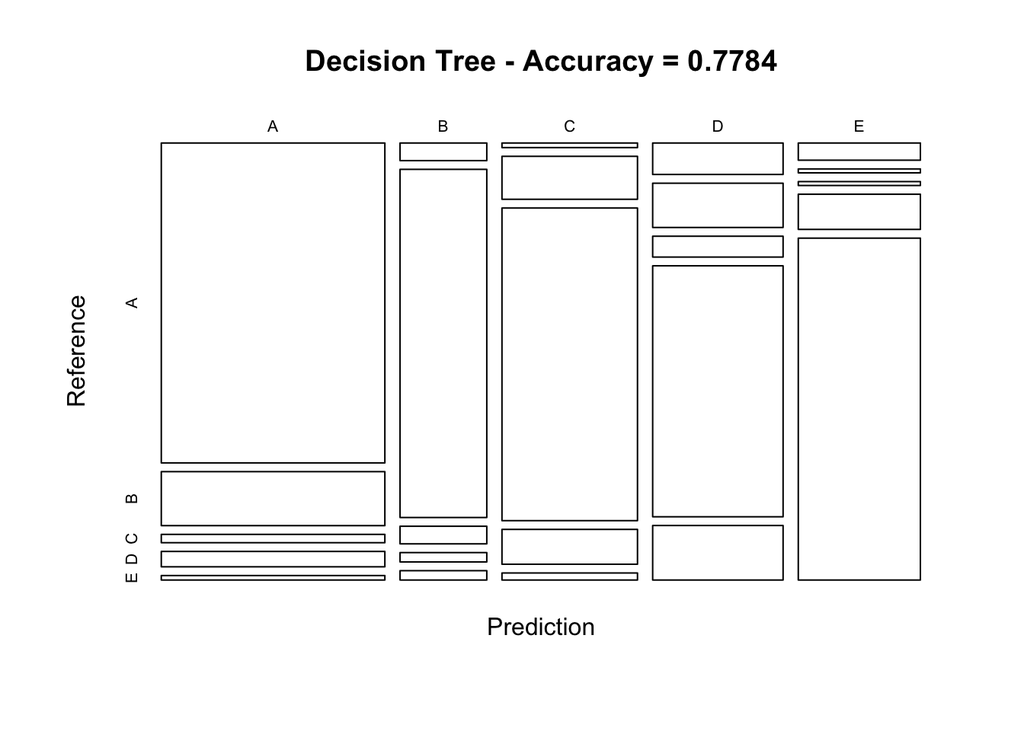

```r
plot(ConfMatDT$table, col = ConfMatDT$byClass,
     main = paste("Decision Tree - Accuracy =",
                  round(ConfMatDT$overall['Accuracy'], 4)))
```

### 3. Generalised Boosted Model

Firstly, we fit the model.

```r
set.seed(291)
ControlGBM <- trainControl(method = "repeatedcv", number = 5, repeats = 1)
ModFitGBM  <- train(classe ~ ., data=TrainSet, method = "gbm",
                    trControl = ControlGBM, verbose = FALSE)
ModFitGBM$finalModel
```

```
## A gradient boosted model with multinomial loss function.
## 150 iterations were performed.
## There were 53 predictors of which 53 had non-zero influence.
```

Then, we run the model on the test dataset.

```r
PredGBM <- predict(ModFitGBM, newdata=TestSet)
ConfMatGBM <- confusionMatrix(PredGBM, TestSet$classe)
ConfMatGBM
```

```
## Confusion Matrix and Statistics
##
##           Reference
## Prediction    A    B    C    D    E
##          A 1669    9    0    1    0
##          B    5 1123    7    2    0
##          C    0    5 1016   15    1
##          D    0    2    2  946   20
##          E    0    0    1    0 1061
##
## Overall Statistics
##
##                Accuracy : 0.9881
##                  95% CI : (0.985, 0.9907)
##     No Information Rate : 0.2845
##     P-Value [Acc > NIR] : < 2.2e-16
##
##                   Kappa : 0.985
##
##  Mcnemar's Test P-Value : NA
##
## Statistics by Class:
##
##                      Class: A Class: B Class: C Class: D Class: E
## Sensitivity            0.9970   0.9860   0.9903   0.9813   0.9806
## Specificity            0.9976   0.9971   0.9957   0.9951   0.9998
## Pos Pred Value         0.9940   0.9877   0.9797   0.9753   0.9991
## Neg Pred Value         0.9988   0.9966   0.9979   0.9963   0.9956
## Prevalence             0.2845   0.1935   0.1743   0.1638   0.1839
## Detection Rate         0.2836   0.1908   0.1726   0.1607   0.1803
## Detection Prevalence   0.2853   0.1932   0.1762   0.1648   0.1805
## Balanced Accuracy      0.9973   0.9915   0.9930   0.9882   0.9902
```

Finally, we plot the confusion matrix in a more visually pleasing (and intuitive) way.

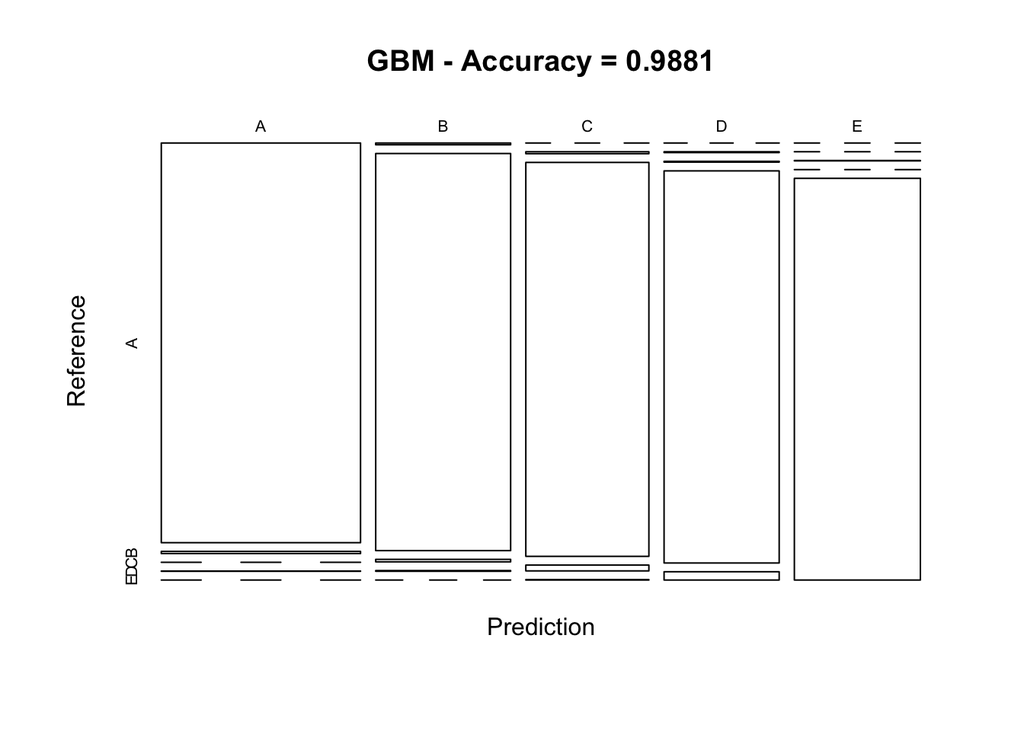

```r
plot(ConfMatGBM$table, col = ConfMatGBM$byClass,
     main = paste("GBM - Accuracy =", round(ConfMatGBM$overall['Accuracy'], 4)))
```

## Applying the Selected Model to the Test Dataset

The accuracies of the three models are: 1. Random Forest: 0.9971  
2. Decision Trees: 0.7784  
3. Generalised Boosted Model: 0.9881

Since the Random Forest model is the most accurate one, we will apply it to the test dataset to predict the results needed for the aforementioned test.

```r
PredictTest <- predict(ModFitRF, newdata=test)
PredictTest
```

```
##  [1] B A B A A E D B A A B C B A E E A B B B
## Levels: A B C D E
```